# Lab6-RMD

Clayton Glenn

February 22, 2018

# 1 Task 1

## 1.1 Get working Directory

```r
getwd()
```

```
## [1] "C:/Users/cglen/Documents/Stat Methods/Labs/LAB6"
```

# 2 Task 2

## 2.1 4 Plots of the norms

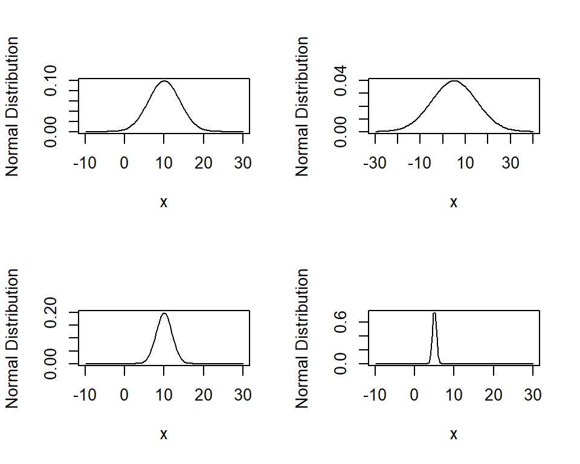

```r
layout(matrix(1:4, nr = 2, nc = 2))

###Normal Density with mu = 10 and sd = 4
curve(dnorm(x, mean = 10, sd =   4),
      xlim = c(-10, 30),
      ylab = "Normal Distribution")

###Normal Density with mu = 10 and sd = 2
curve(dnorm(x, mean = 10, sd =   2),
      xlim = c(-10, 30),
      ylab = "Normal Distribution")

###Normal Density with mu = 5 and sd = 10
curve(dnorm(x, mean =  5, sd =  10),
      xlim = c(-30, 40),
      ylab = "Normal Distribution")

###Normal Density with mu = 5 and sd = .5
curve(dnorm(x, mean =  5, sd = 1 / 2),
      xlim = c(-10, 30),
      ylab = "Normal Distribution")
```

## 2.2 Plot the norms and show probability

### 2.2.1 Plot the norm of mean = 0 and sd = 1 and show probability of 2:30

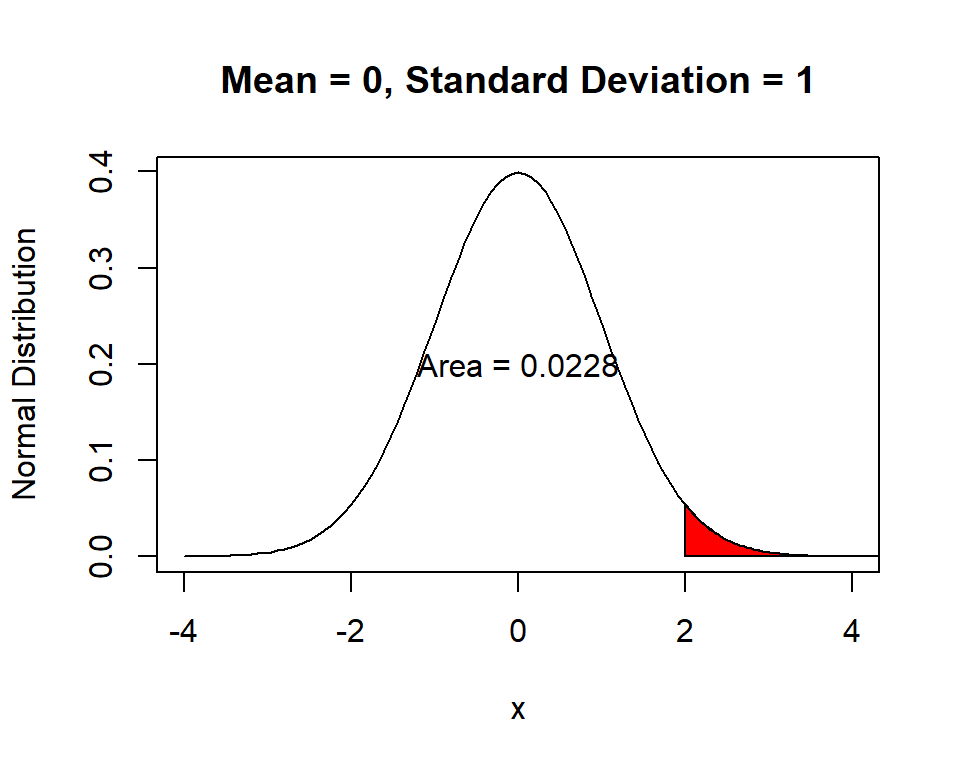

```r
curve(
  dnorm(x, mean = 0, sd = 1),
  xlim = c(-4, 4),
  ylab = "Normal Distribution",
  main = "Mean = 0, Standard Deviation = 1"
)
xcurve = seq(2, 30, length = 1000)
ycurve = dnorm(xcurve, mean = 0, sd = 1)
polygon(c(2, xcurve, 30), c(0, ycurve, 0), col = "Red")
prob = pnorm(30, mean = 0, sd = 1) - pnorm(2, mean = 0, sd = 1)
prob = round(prob, 4)
text(x = 0,
     y = 1 / 2 * dnorm(0, 0, 1),
     paste("Area = ", prob, sep = ""))
```

### 2.2.2 Plot the norm of mean = 4 and sd = 2 and show probability of 1:5

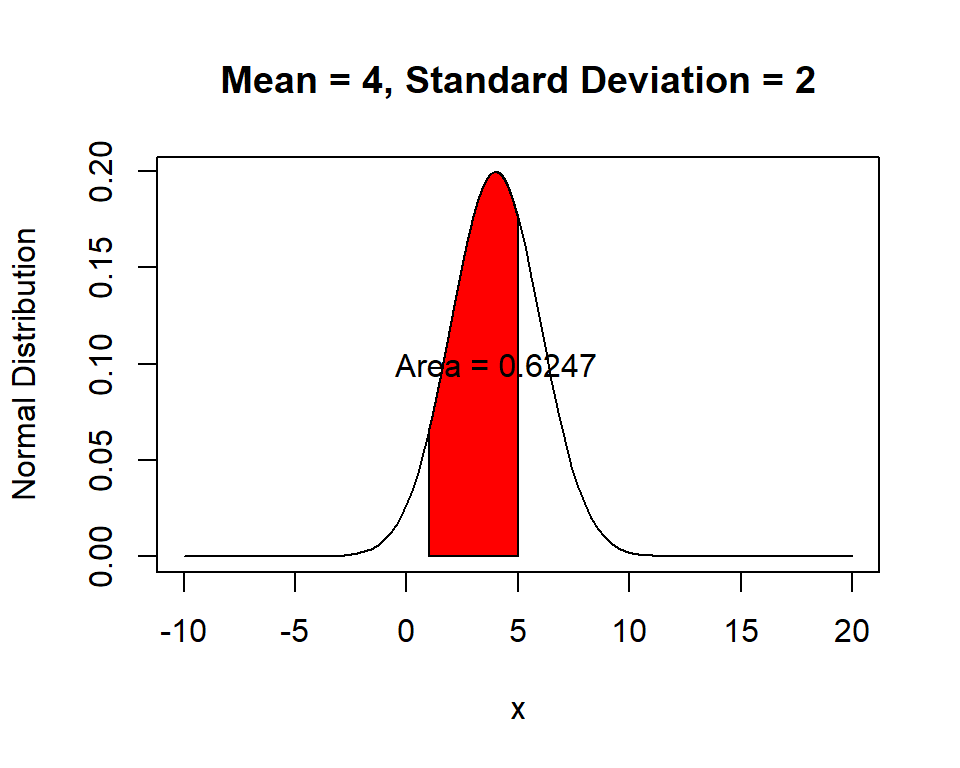

```r
curve(
  dnorm(x, mean = 4, sd = 2),
  xlim = c(-10, 20),
  ylab = "Normal Distribution",
  main = "Mean = 4, Standard Deviation = 2"
)
xcurve = seq(1, 5, length = 1000)
ycurve = dnorm(xcurve, mean = 4, sd = 2)
polygon(c(1, xcurve, 5), c(0, ycurve, 0), col = "Red")
prob = pnorm(5, mean = 4, sd = 2) - pnorm(1, mean = 4, sd = 2)
prob = round(prob, 4)
text(x = 4,
     y = 1 / 2 * dnorm(4, 4, 2),
     paste("Area = ", prob, sep = ""))
```

### 2.2.3 Plot the norm of mean = 10 and sd = 4 and show probability of -30:10

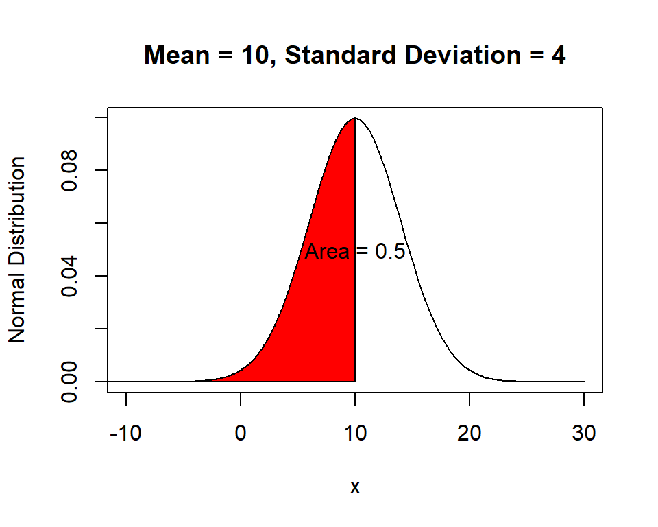

```r
curve(
  dnorm(x, mean = 10, sd = 4),
  xlim = c(-10, 30),
  ylab = "Normal Distribution",
  main = "Mean = 10, Standard Deviation = 4"
)
xcurve = seq(-30, 10, length = 1000)
ycurve = dnorm(xcurve, mean = 10, sd = 4)
polygon(c(-30, xcurve, 10), c(0, ycurve, 0), col = "Red")
prob = pnorm(10, mean = 10, sd = 4) - pnorm(-30, mean = 10, sd = 4)
prob = round(prob, 4)
text(x = 10,
     y = 1 / 2 * dnorm(10, 10, 4),
     paste("Area = ", prob, sep = ""))
```

### 2.2.4 Plot the norm of mean = -2 and sd = 0.5 and show probability of -3:-2

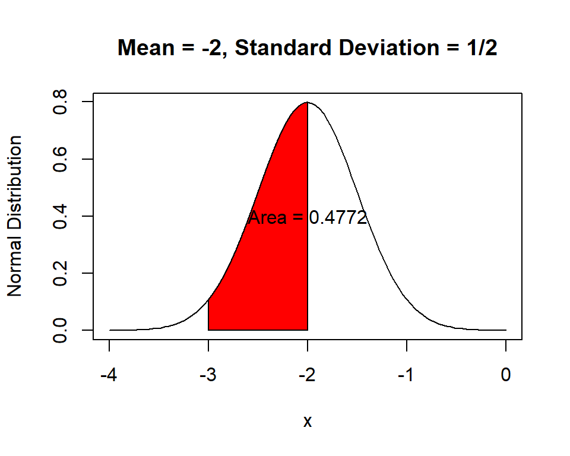

```r
curve(
  dnorm(x, mean = -2, sd = 1 / 2),
  xlim = c(-4, 0),
  ylab = "Normal Distribution",
  main = "Mean = -2, Standard Deviation = 1/2"
)
xcurve = seq(-3, -2, length = 1000)
ycurve = dnorm(xcurve, mean = -2, sd = 1 / 2)
polygon(c(-3, xcurve, -2), c(0, ycurve, 0), col = "Red")
prob = pnorm(-2, mean = -2, sd = 1 / 2) - pnorm(-3, mean = -2, sd = 1 / 2)
prob = round(prob, 4)
text(x = -2,
     y = 1 / 2 * dnorm(-2, -2, 1 / 2),
     paste("Area = ", prob, sep = ""))
```

# 3 Task 3

## 3.1 Plot the Gamma Distribution

### 3.1.1 Plot the gamma with shape = 1 and scale = 1

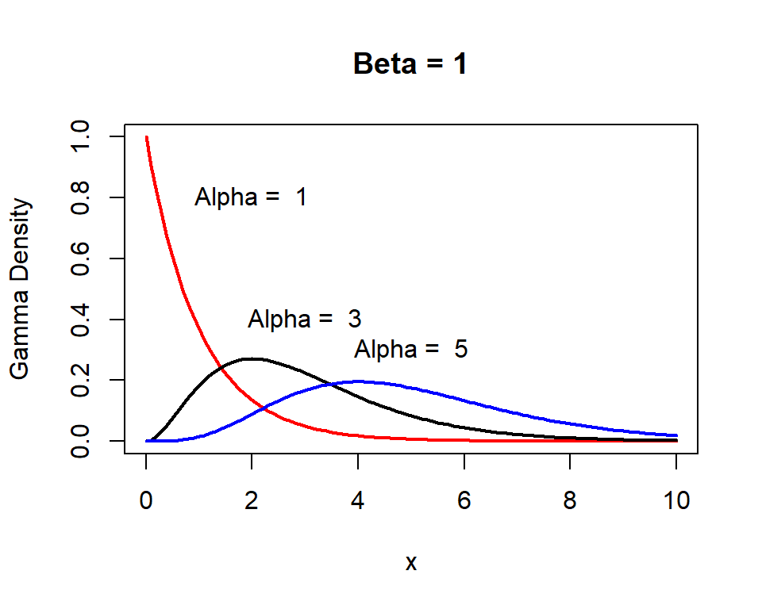

```r
curve(
  dgamma(x, shape = 1, scale = 1),
  xlim = c(0, 10),
  ylim = c(0, 1),
  col = "Red",
  lwd = 2,
  ylab = "Gamma Density",
  main = "Beta = 1"
)
text(x = 2, y = 0.8, paste("Alpha = ", 1))

###Plot the gamma with shape = 3 and scale = 1
curve(
  dgamma(x, shape = 3, scale = 1),
  xlim = c(0, 10),
  ylim = c(0, 1),
  add = TRUE,
  lwd = 2
)
text(x = 3, y = 0.4, paste("Alpha = ", 3))

###Plot the gamma with shape = 5 and scale = 1
curve(
  dgamma(x, shape = 5, scale = 1),
  xlim = c(0, 10),
  ylim = c(0, 1),
  add = TRUE,
  col = "Blue",
  lwd = 2
)
text(x = 5, y = 0.3, paste("Alpha = ", 5))
```

## 3.2 Gamma Plots with Probabilities

### 3.2.1 Plot the gamma with shape = 3 and scale = 2 and show probability of 2:5

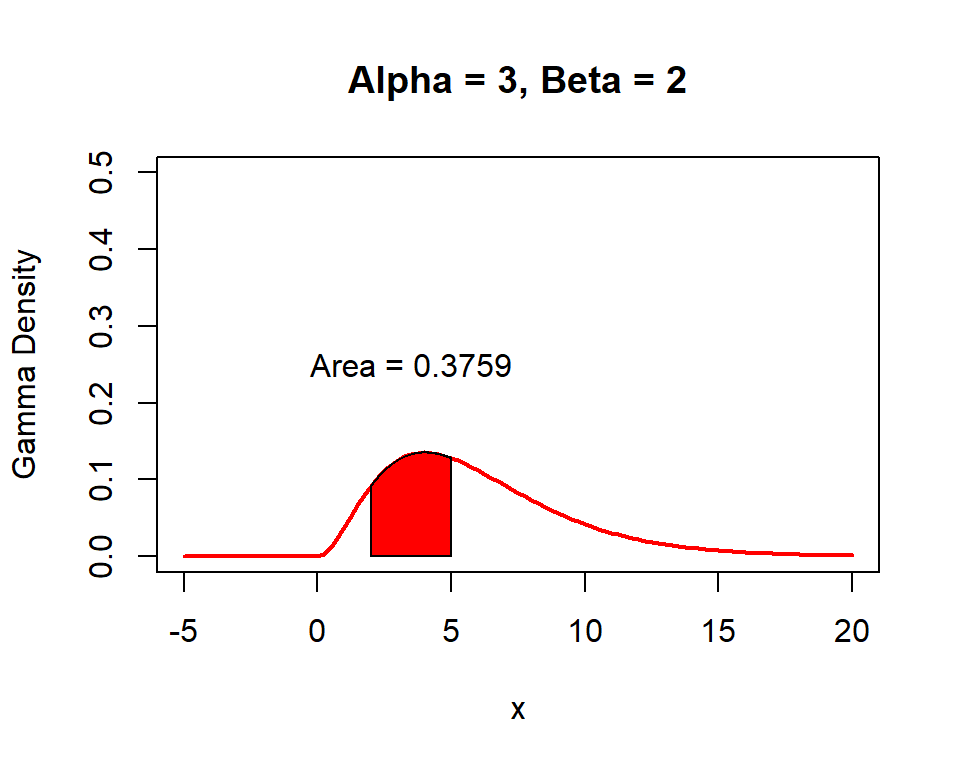

```r
curve(
  dgamma(x, shape = 3, scale = 2),
  xlim = c(-5, 20),
  ylim = c(0, .5),
  col = "Red",
  lwd = 2,
  ylab = "Gamma Density",
  main = "Alpha = 3, Beta = 2"
)
xcurve = seq(2, 5, length = 1000)
ycurve = dgamma(xcurve, shape = 3, scale = 2)
polygon(c(2, xcurve, 5), c(0, ycurve, 0), col = "Red")
prob = pgamma(5, shape = 3, scale = 2) - pgamma(2, shape = 3, scale = 2)
prob = round(prob, 4)
text(
  x = (2 + 5) / 2,
  y = 2 * dgamma(3, shape = 3, scale = 2),
  paste("Area = ", prob, sep = "")
)
```

### 3.2.2 Plot the gamma with shape = 6 and scale = 3 and show probability of 1:4

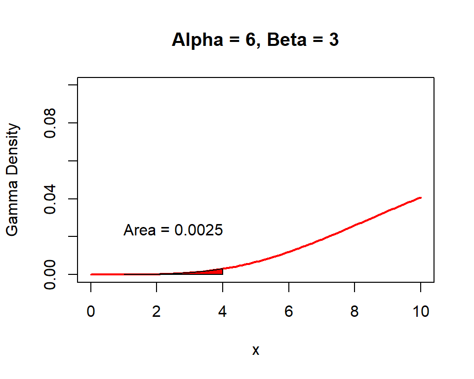

```r
curve(
  dgamma(x, shape = 6, scale = 3),
  xlim = c(0, 10),
  ylim = c(0, .1),
  col = "Red",
  lwd = 2,
  ylab = "Gamma Density",
  main = "Alpha = 6, Beta = 3"
)
xcurve = seq(1, 4, length = 1000)
ycurve = dgamma(xcurve, shape = 6, scale = 3)
polygon(c(1, xcurve, 4), c(0, ycurve, 0), col = "Red")
prob = pgamma(4, shape = 6, scale = 3) - pgamma(1, shape = 6, scale = 3)
prob = round(prob, 4)
text(
  x = (1 + 4) / 2,
  y = 2 * dgamma(6, shape = 6, scale = 3),
  paste("Area = ", prob, sep = "")
)
```

### 3.2.3 Plot the gamma with shape = 2 and scale = 4 and show probability of 3:6

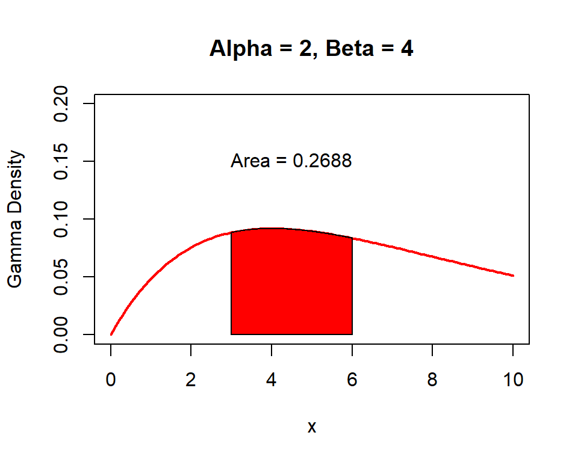

```r
curve(
  dgamma(x, shape = 2, scale = 4),
  xlim = c(0, 10),
  ylim = c(0, .2),
  col = "Red",
  lwd = 2,
  ylab = "Gamma Density",
  main = "Alpha = 2, Beta = 4"
)
xcurve = seq(3, 6, length = 1000)
ycurve = dgamma(xcurve, shape = 2, scale = 4)
polygon(c(3, xcurve, 6), c(0, ycurve, 0), col = "Red")
prob = pgamma(6, shape = 2, scale = 4) - pgamma(3, shape = 2, scale = 4)
prob = round(prob, 4)
text(
  x = (3 + 6) / 2,
  y = 2 * dgamma(2, shape = 2, scale = 4),
  paste("Area = ", prob, sep = "")
)
```

# 4 Task 4

## 4.1 4 Plots of Chisq Density

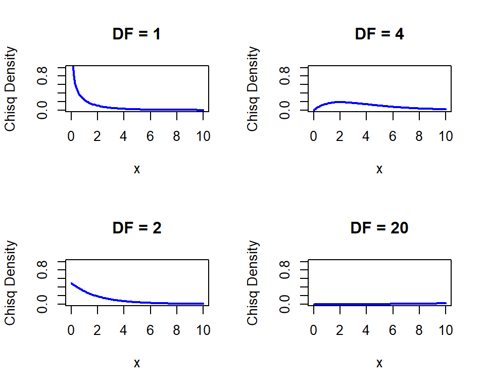

```r
layout(matrix(1:4, nr = 2, nc = 2))

###Plot of Chisq Density with Degrees of Freedom = 1
curve(
  dchisq(x, df = 1),
  xlim = c(0, 10),
  ylim = c(0, 1),
  col = "Blue",
  lwd = 2,
  ylab = "Chisq Density",
  main = "DF = 1"
)

###Plot of Chisq Density with Degrees of Freedom = 2
curve(
  dchisq(x, df = 2),
  xlim = c(0, 10),
  ylim = c(0, 1),
  col = "Blue",
  lwd = 2,
  ylab = "Chisq Density",
  main = "DF = 2"
)

###Plot of Chisq Density with Degrees of Freedom = 4
curve(
  dchisq(x, df = 4),
  xlim = c(0, 10),
  ylim = c(0, 1),
  col = "Blue",
  lwd = 2,
  ylab = "Chisq Density",
  main = "DF = 4"
)

###Plot of Chisq Density with Degrees of Freedom = 20
curve(
  dchisq(x, df = 20),
  xlim = c(0, 10),
  ylim = c(0, 1),
  col = "Blue",
  lwd = 2,
  ylab = "Chisq Density",
  main = "DF = 20"
)
```

## 4.2 Plot Chisq Density With Probabilities

### 4.2.1 Plot of Chisq Density with Degrees of Freedom = 2 and show probability of 2:4

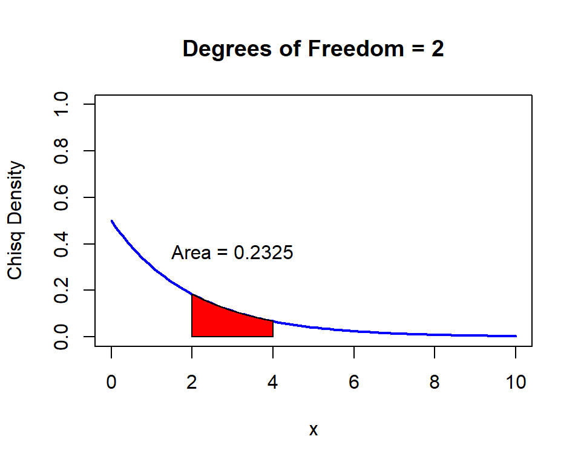

```r
curve(
  dchisq(x, df = 2),
  xlim = c(0, 10),
  ylim = c(0, 1),
  col = "Blue",
  lwd = 2,
  ylab = "Chisq Density",
  main = "Degrees of Freedom = 2"
)
xcurve = seq(2, 4, length = 1000)
ycurve = dchisq(xcurve, df = 2)
polygon(c(2, xcurve, 4), c(0, ycurve, 0), col = "Red")
prob = pchisq(4, df = 2) - pchisq(2, df = 2)
prob = round(prob, 4)
text(x = (2 + 4) / 2,
     y = 2 * dchisq(2, df = 2),
     paste("Area = ", prob, sep = ""))
```

### 4.2.2 Plot of Chisq Density with Degrees of Freedom = 3 and show probability of 3:5

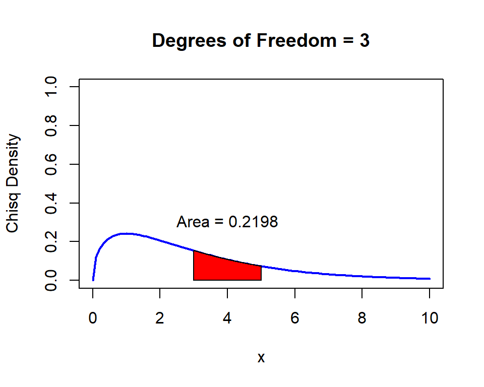

```r
curve(
  dchisq(x, df = 3),
  xlim = c(0, 10),
  ylim = c(0, 1),
  col = "Blue",
  lwd = 2,
  ylab = "Chisq Density",
  main = "Degrees of Freedom = 3"
)
xcurve = seq(3, 5, length = 1000)
ycurve = dchisq(xcurve, df = 3)
polygon(c(3, xcurve, 5), c(0, ycurve, 0), col = "Red")
prob = pchisq(5, df = 3) - pchisq(3, df = 3)
prob = round(prob, 4)
text(x = (3 + 5) / 2,
     y = 2 * dchisq(3, df = 3),
     paste("Area = ", prob, sep = ""))
```

### 4.2.3 Plot of Chisq Density with Degrees of Freedom = 20 and show probability of 10:21

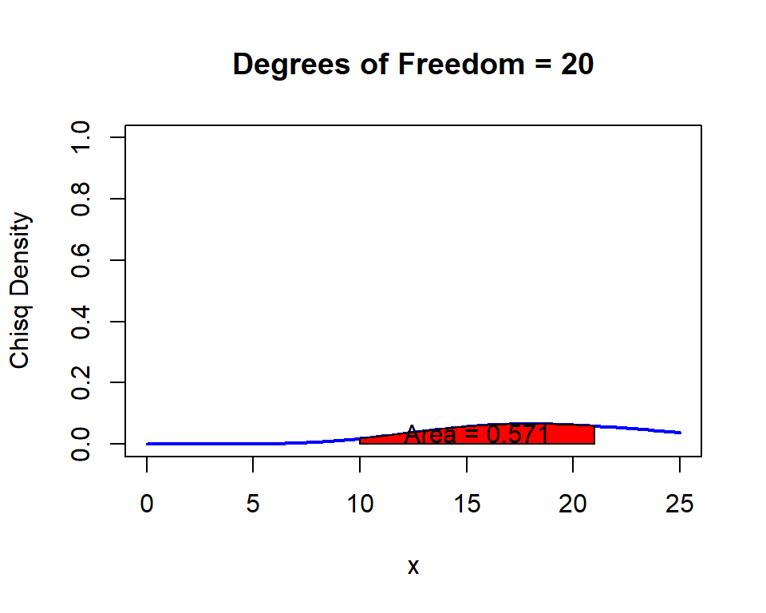

```r
curve(
  dchisq(x, df = 20),
  xlim = c(0, 25),
  ylim = c(0, 1),
  col = "Blue",
  lwd = 2,
  ylab = "Chisq Density",
  main = "Degrees of Freedom = 20"
)
xcurve = seq(10, 21, length = 1000)
ycurve = dchisq(xcurve, df = 20)
polygon(c(10, xcurve, 21), c(0, ycurve, 0), col = "Red")
prob = pchisq(21, df = 20) - pchisq(10, df = 20)
prob = round(prob, 4)
text(x = (10 + 21) / 2,
     y = 2 * dchisq(10, df = 20),
     paste("Area = ", prob, sep = ""))
```

# 5 Task 5

## 5.1 Plots of Weibull Density with Probability

### 5.1.1 Plot of Weibull Density with shape = 2 and scale = 1 and show probability of 1:2

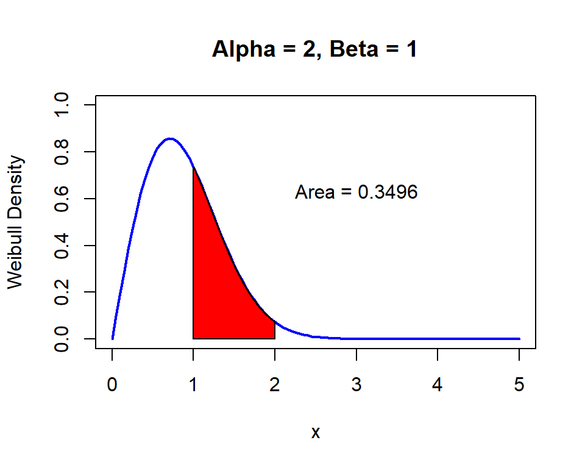

```r
curve(
  dweibull(x, shape = 2, scale = 1),
  xlim = c(0, 5),
  ylim = c(0, 1),
  col = "Blue",
  lwd = 2,
  ylab = "Weibull Density",
  main = "Alpha = 2, Beta = 1"
)
xcurve = seq(1, 2, length = 1000)
ycurve = dweibull(xcurve, shape = 2, scale = 1)
polygon(c(1, xcurve, 2), c(0, ycurve, 0), col = "Red")
prob = pweibull(2, shape = 2, scale = 1) - pweibull(1, shape = 2, scale = 1)
prob = round(prob, 4)
text(
  x = 3,
  y = 2 * dweibull(1.5, shape = 2, scale = 1),
  paste("Area = ", prob, sep = "")
)
```

### 5.1.2 Plot of Weibull Density with shape = 5 and scale = 4 and show probability of 3:5

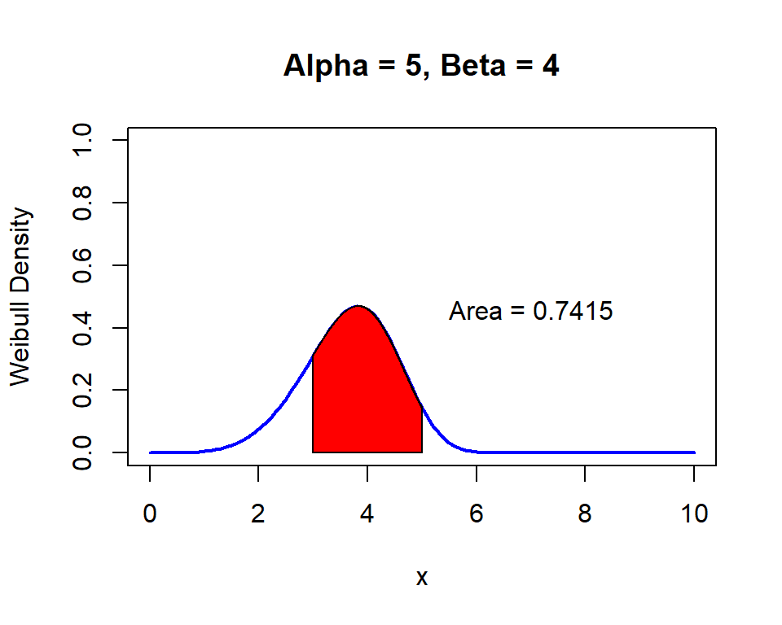

```r
curve(
  dweibull(x, shape = 5, scale = 4),
  xlim = c(0, 10),
  ylim = c(0, 1),
  col = "Blue",
  lwd = 2,
  ylab = "Weibull Density",
  main = "Alpha = 5, Beta = 4"
)
xcurve = seq(3, 5, length = 1000)
ycurve = dweibull(xcurve, shape = 5, scale = 4)
polygon(c(3, xcurve, 5), c(0, ycurve, 0), col = "Red")
prob = pweibull(5, shape = 5, scale = 4) - pweibull(3, shape = 5, scale = 4)
prob = round(prob, 4)
text(
  x = 7,
  y = 1 * dweibull(4, shape = 5, scale = 4),
  paste("Area = ", prob, sep = "")
)
```

### 5.1.3 Plot of Weibull Density with shape = 4 and scale = 10 and show probability of 8:9

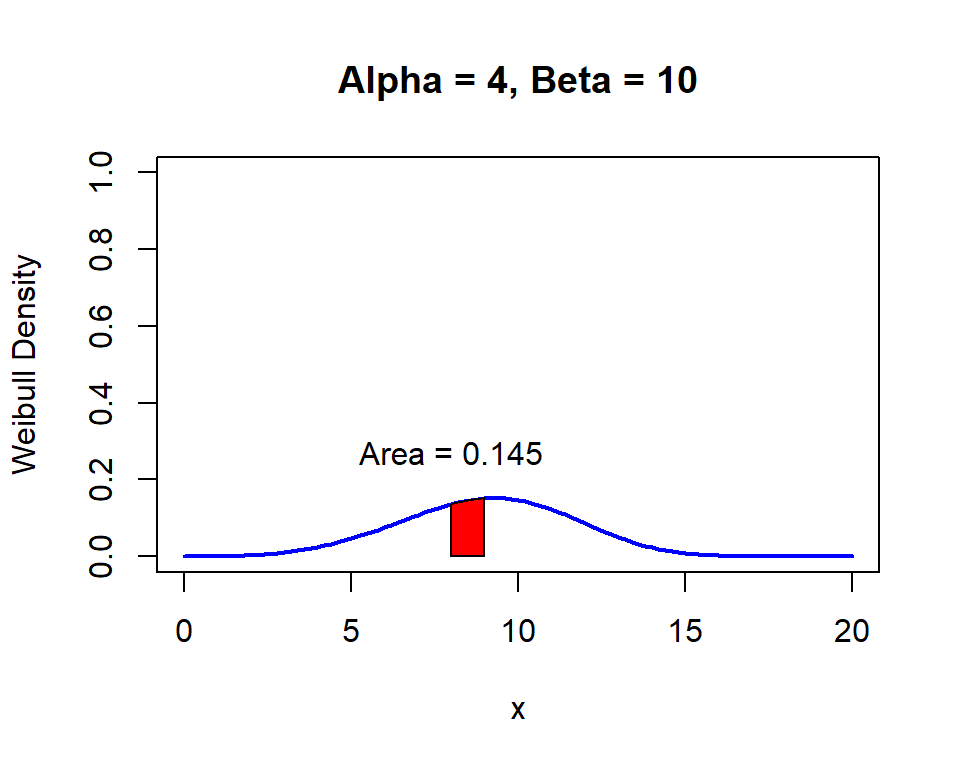

```r
curve(
  dweibull(x, shape = 4, scale = 10),
  xlim = c(0, 20),
  ylim = c(0, 1),
  col = "Blue",
  lwd = 2,
  ylab = "Weibull Density",
  main = "Alpha = 4, Beta = 10"
)
xcurve = seq(8, 9, length = 1000)
ycurve = dweibull(xcurve, shape = 4, scale = 10)
polygon(c(8, xcurve, 9), c(0, ycurve, 0), col = "Red")
prob = pweibull(9, shape = 4, scale = 10) - pweibull(8, shape = 4, scale = 10)
prob = round(prob, 4)
text(
  x = 8,
  y = 2 * dweibull(8, shape = 4, scale = 10),
  paste("Area = ", prob, sep = "")
)
```

### 5.1.4 Plot of Weibull Density with shape = 8 and scale = 8 and show probability of 7:9

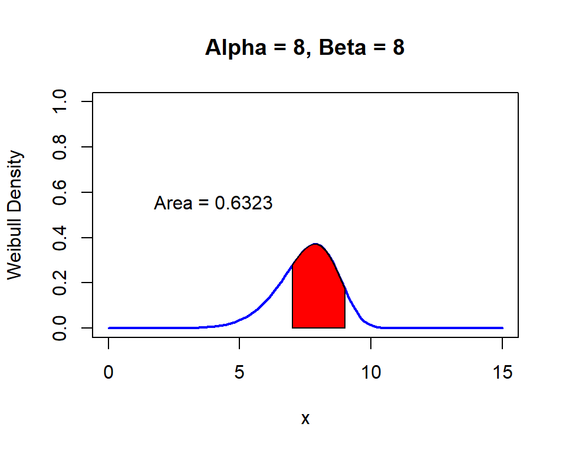

```r
curve(
  dweibull(x, shape = 8, scale = 8),
  xlim = c(0, 15),
  ylim = c(0, 1),
  col = "Blue",
  lwd = 2,
  ylab = "Weibull Density",
  main = "Alpha = 8, Beta = 8"
)
xcurve = seq(7, 9, length = 1000)
ycurve = dweibull(xcurve, shape = 8, scale = 8)
polygon(c(7, xcurve, 9), c(0, ycurve, 0), col = "Red")
prob = pweibull(9, shape = 8, scale = 8) - pweibull(7, shape = 8, scale = 8)
prob = round(prob, 4)
text(
  x = 4,
  y = 2 * dweibull(7, shape = 8, scale = 8),
  paste("Area = ", prob, sep = "")
)
```

# 6 Task 6

## 6.1 Beta Plots with Distributions

### 6.1.1 Plot of Beta Density with shape1 = 2 and shape2 = 1 and show probability of 0:1

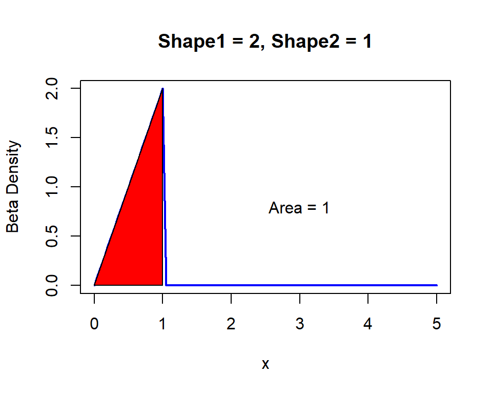

```r
curve(
  dbeta(x, shape1 = 2, shape2 = 1),
  xlim = c(0, 5),
  ylim = c(0, 2),
  col = "Blue",
  lwd = 2,
  ylab = "Beta Density",
  main = "Shape1 = 2, Shape2 = 1"
)
xcurve = seq(0, 1, length = 1000)
ycurve = dbeta(xcurve, shape1 = 2, shape2 = 1)
polygon(c(0, xcurve, 1), c(0, ycurve, 0), col = "Red")
prob = pbeta(1, shape1 = 2, shape2 = 1) - pbeta(0, shape1 = 2, shape2 = 1)
prob = round(prob, 4)
text(x = 3,
     y = 0.8,
     paste("Area = ", prob, sep = ""))
```

### 6.1.2 Plot of Beta Density with shape1 = 1 and shape2 = 2 and show probability of .5:1

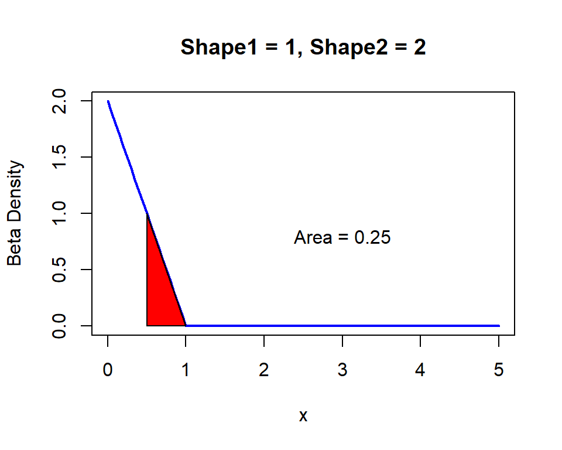

```r
curve(
  dbeta(x, shape1 = 1, shape2 = 2),
  xlim = c(0, 5),
  ylim = c(0, 2),
  col = "Blue",
  lwd = 2,
  ylab = "Beta Density",
  main = "Shape1 = 1, Shape2 = 2"
)
xcurve = seq(.5, 1, length = 1000)
ycurve = dbeta(xcurve, shape1 = 1, shape2 = 2)
polygon(c(.5, xcurve, 1), c(0, ycurve, 0), col = "Red")
prob = pbeta(1, shape1 = 1, shape2 = 2) - pbeta(.5, shape1 = 1, shape2 = 2)
prob = round(prob, 4)
text(x = 3,
     y = 0.8,
     paste("Area = ", prob, sep = ""))
```

### 6.1.3 Plot of Beta Density with shape1 = 5 and shape2 = 10 and show probability of .3:.6

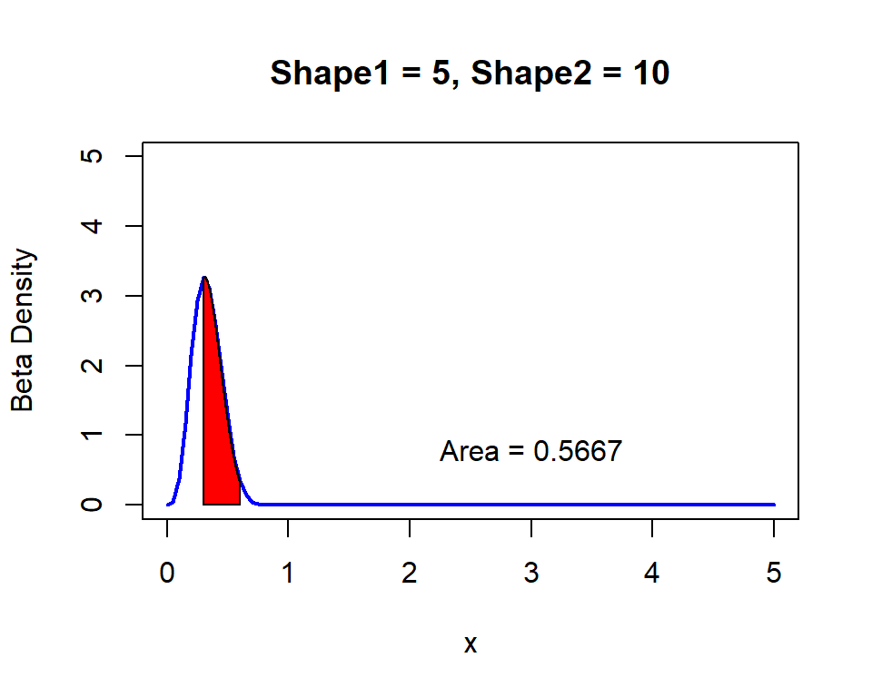

```r
curve(
  dbeta(x, shape1 = 5, shape2 = 10),
  xlim = c(0, 5),
  ylim = c(0, 5),
  col = "Blue",
  lwd = 2,
  ylab = "Beta Density",
  main = "Shape1 = 5, Shape2 = 10"
)
xcurve = seq(.3, .6, length = 1000)
ycurve = dbeta(xcurve, shape1 = 5, shape2 = 10)
polygon(c(.3, xcurve, .6), c(0, ycurve, 0), col = "Red")
prob = pbeta(.6, shape1 = 5, shape2 = 10) - pbeta(.3, shape1 = 5, shape2 = 10)
prob = round(prob, 4)
text(x = 3,
     y = 0.8,
     paste("Area = ", prob, sep = ""))
```

### 6.1.4 Plot of Beta Density with shape1 = 10 and shape2 = 5 and show probability of 0:.5

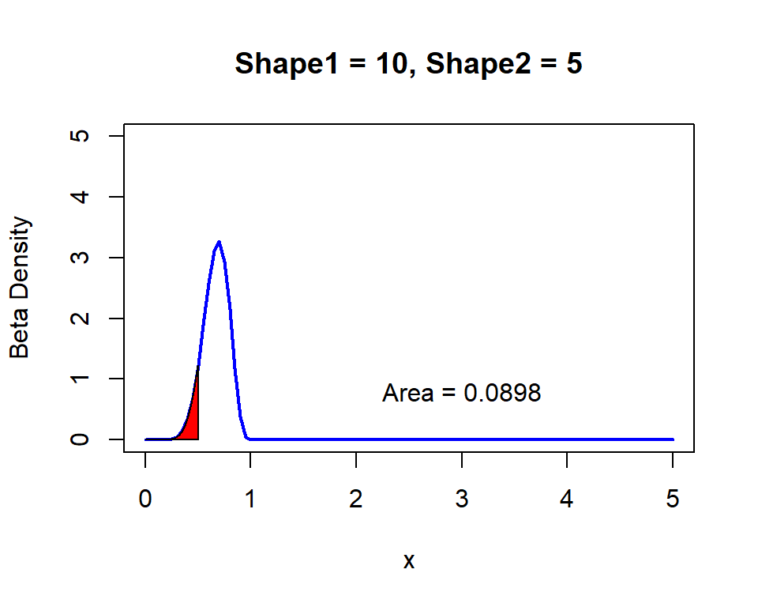

```r
curve(
  dbeta(x, shape1 = 10, shape2 = 5),
  xlim = c(0, 5),
  ylim = c(0, 5),
  col = "Blue",
  lwd = 2,
  ylab = "Beta Density",
  main = "Shape1 = 10, Shape2 = 5"
)
xcurve = seq(0, .5, length = 1000)
ycurve = dbeta(xcurve, shape1 = 10, shape2 = 5)
polygon(c(0, xcurve, .5), c(0, ycurve, 0), col = "Red")
prob = pbeta(.5, shape1 = 10, shape2 = 5) - pbeta(0, shape1 = 10, shape2 = 5)
prob = round(prob, 4)
text(x = 3,
     y = 0.8,
     paste("Area = ", prob, sep = ""))
```

# 7 Task 7

## 7.1 Homemade function to take alpha and beta values to create an exponential plot

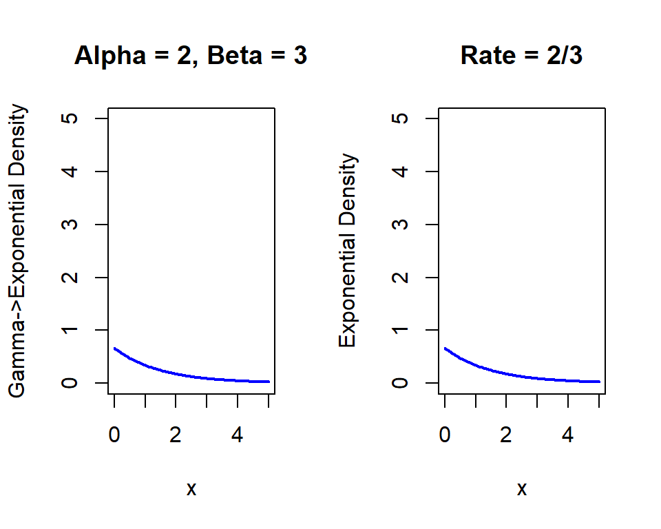

```r
myexp = function(x, a, b) {
  (a / b) * '^'(2.71828183,-(a * x / b))
}

##Show Both plots side by side to compare all x values
layout(matrix(1:2, nr = 1, nc = 2))

###Gamma->Exponential with 2:3
curve(
  myexp(x, 2, 3),
  xlim = c(0, 5),
  ylim = c(0, 5),
  col = "Blue",
  lwd = 2,
  ylab = "Gamma->Exponential Density",
  main = "Alpha = 2, Beta = 3"
)

###Exponential with rate 2/3
curve(
  dexp(x, rate = 2 / 3),
  xlim = c(0, 5),
  ylim = c(0, 5),
  col = "Blue",
  lwd = 2,
  ylab = "Exponential Density",
  main = "Rate = 2/3"
)
```